# PROJECT TDI

### PROPOSED CAPSTONE PROJECT -THE DATA INCUBATOR

#### NAME: Grace I. Ufeoshi

#### PROJECT TITLE: Corporate Road-map for Corporations to be listed as part of JUST Capital Top 100

###### BACKGROUND

*JUST Capital is a nonprofit that provides information and rankings on how large corporations perform on issues that matter most to the public. They help people, companies, and markets do the right thing by tracking the business behaviors Americans care most about. They give individuals a voice on what really matters to them and evaluate how companies perform on those issues. By providing the right knowledge and making it easy to access and understand, JUST capital believes capital will flow to corporations that are more JUST, ultimately leading to a balanced business world that considers human needs that are so often neglected today. The meaning of JUST is defined by the American public as fair, equitable and balanced. In 2016, JUST Capital surveyed nearly 4,000 Americans from all regions and walks of life, in its second annual Poll on Corporate America. The issues identified by the public form the basis of her benchmark — it is against these Drivers and Components that corporate performance is measured. The most important factors broadly relate to employees, customers, company leadership, the environment, communities and investors. JUST Capital assessed and ranked 897 of the largest publicly-traded companies in America. Out of these, there are 100 corporation ranked as the Top 100. I will be analyzing the top half of the 897 companies in order to identify viable trends.*

###### MOTIVATION

To build a more Just marketplace, assist more companies climb up the Just 100 rating ladder, and to establish more just processes, systems and cultures, I propose to develop a model that helps companies establish the top three components that should be improve upon, and what impact these components will have on their just ranking. Furthermore, this will help ccompanies to be able to know where they stand as regards their ranking.

##### ANALYSIS TO BE PERFORMED

1. From a corporation’s perspective, i want to identify what actions companies can take to have the greatest impact on JUST Score, Rank and Inclusion in the JUST 100.
2. What are the top three components a company should improve upon, in each industry, to have the greatest impact on their JUST ranking.
3. By industry, what factors drive the differences between companies?
4. To identify the effect of the top three component on companies not ranked in the JUST 100. Will these components improve their JUST Score and Rank? By how many percent?
5. To identify why the industry not included in the JUST 100 have low ranking, what should be focused on and what not?
6. To predict which companies will be in the JUST 100 in subsequent years based on the trend identified from previous years and the components they improve on.

##### Further work

1. Futher analysis will be carried out predict which companies will be in the JUST 100 in subsequent years based on the trend identified from previous years and the components they improve on.

###### Data Sources

1. JUST CAPITAL corporate performance scores: https://justcapital.com/s/COMPANY_SCORES_TOP_HALF.xlsx
2. Metric Legend: This document provides an overview of the ranking mode performance indicators or metrics. Metric codes, used in subsequent projects, as well as metric definitions, can be found within this document. https://justcapital.com/s/metrics_table.xlsx
3. Just Capital Companies Data: https://justcapital.com/s/COMPANY_DATA.xlsx

### Exploratory Data Analysis and Results

```python
import pandas as pd
import matplotlib.pyplot as plt
import seaborn as sns
sns.set()
%matplotlib inline
```

```python
just400 = pd.read_excel("COMPANY_SCORES_TOP_HALF_NoPassword.xlsx", sheet_name="Sheet1")
```

```python
just400.head() # This shows the first 5 record in  the dataset
```

|  | id | JUST_IND | JUST_100 | WGT_SCORE | PAY | TREAT | SUPPLY | COMM | JOBS | PROD | ... | LEAD.INTEGRITY | LEAD.TRUTH | LEAD.TAX | LEAD.POLITICS | ENV.POLLUTION | ENV.MGMT | ENV.EFFICIENT | INVEST.ACCURATE | INVEST.PROFIT | INVEST.RETURN |
| --- | --- | --- | --- | --- | --- | --- | --- | --- | --- | --- | --- | --- | --- | --- | --- | --- | --- | --- | --- | --- | --- |
| 0 | 1 | 1 | No | 51.817449 | 62.264831 | 58.014902 | 59.868173 | 54.221668 | 103.931869 | 26.161618 | ... | 70.922283 | -93.676223 | 92.427544 | 79.633970 | 48.675674 | 54.653723 | 87.660818 | 35.348026 | 85.924506 | 61.828625 |
| 1 | 2 | 1 | Yes | 60.214518 | 64.066467 | 65.888751 | 62.777286 | 85.099846 | 34.345494 | 74.043539 | ... | 47.569446 | 54.225771 | 73.799465 | 60.975544 | 46.513131 | 62.652554 | 81.376922 | 35.348026 | 46.837676 | 64.342789 |
| 2 | 5 | 1 | No | 50.084911 | 53.257429 | 62.476653 | 55.205684 | 56.946310 | 42.497728 | 75.957935 | ... | 68.533617 | 54.225771 | 54.129631 | 69.755980 | 8.109127 | 13.349142 | 19.602621 | 35.348026 | 28.431830 | 58.634653 |
| 3 | 7 | 1 | No | 52.567243 | 47.376425 | 58.975030 | 46.857584 | 56.946310 | 50.000000 | 54.717232 | ... | 32.293719 | 54.225771 | 59.415758 | 71.951089 | 43.630359 | 62.652554 | 48.207416 | 67.399219 | 48.599573 | 68.826147 |
| 4 | 9 | 1 | No | 50.798780 | 47.990529 | 53.692387 | 45.463432 | 37.310563 | 50.000000 | 33.423107 | ... | 61.407710 | 54.225771 | 48.212212 | 50.000000 | 68.238392 | 44.911560 | 54.625216 | 67.399219 | 13.970277 | 87.256794 |

5 rows × 50 columns

```python
just400.info() #showing the feautures in the dataset
```

```
<class 'pandas.core.frame.DataFrame'>
RangeIndex: 440 entries, 0 to 439
Data columns (total 50 columns):
id                 440 non-null int64
JUST_IND           440 non-null int64
JUST_100           440 non-null object
WGT_SCORE          440 non-null float64
PAY                440 non-null float64
TREAT              440 non-null float64
SUPPLY             440 non-null float64
COMM               440 non-null float64
JOBS               440 non-null float64
PROD               440 non-null float64
CUST               440 non-null float64
LEAD               440 non-null float64
ENV                440 non-null float64
INVEST             440 non-null float64
PAY.LIVING         440 non-null float64
PAY.PTO            440 non-null float64
PAY.HEALTH         440 non-null float64
PAY.FAIR           440 non-null float64
PAY.RETIRE         440 non-null float64
PAY.DISC           440 non-null float64
PAY.CEO            440 non-null float64
TREAT.SAFE         440 non-null float64
TREAT.WLB          440 non-null float64
TREAT.EDU          440 non-null float64
TREAT.DISC         440 non-null float64
TREAT.LAYOFF       440 non-null float64
TREAT.RESPECT      440 non-null float64
SUPPLY.ABUSE       440 non-null float64
SUPPLY.CONFLICT    440 non-null float64
SUPPLY.REPRESS     440 non-null float64
COMM.RELS          440 non-null float64
COMM.CHARITY       440 non-null float64
JOBS.US            440 non-null float64
PROD.BEN           440 non-null float64
PROD.QUAL          440 non-null float64
CUST.FAIR          440 non-null float64
CUST.RELS          440 non-null float64
CUST.DISC          440 non-null int64
CUST.PRIV          440 non-null float64
LEAD.LAWS          440 non-null float64
LEAD.INTEGRITY     440 non-null float64
LEAD.TRUTH         440 non-null float64
LEAD.TAX           440 non-null float64
LEAD.POLITICS      440 non-null float64
ENV.POLLUTION      440 non-null float64
ENV.MGMT           440 non-null float64
ENV.EFFICIENT      440 non-null float64
INVEST.ACCURATE    440 non-null float64
INVEST.PROFIT      440 non-null float64
INVEST.RETURN      440 non-null float64
dtypes: float64(46), int64(3), object(1)
memory usage: 172.0+ KB
```

```
Text(0.5,1,'Ratio of the companies in the top 100 to the ones not in the top 100')
```

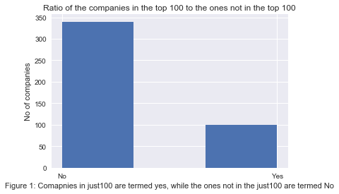

```python
#A graph showing the ratio between the companies in the top 100 and the ones not in the top 100
plt.hist(just400["JUST_100"], bins= 3)
plt.xlabel("Figure 1: Comapnies in just100 are termed yes, while the ones not in the just100 are termed No")
plt.ylabel("No of companies")
plt.title("Ratio of the companies in the top 100 to the ones not in the top 100")
```

### Results

- The above graph shows the ratio between the companies in the top 100 to the ones not in the top 100.

```python
# This selects the companies within the just100 ranking
just100=just400[just400["JUST_100"] == "Yes"]
```

```python
# This selects the companies not within the just100 ranking
notjust100=just400[just400["JUST_100"] == "No"]
```

```python
# This calculates the average score of companies within the just100 ranking with respect to the rating components
meanJust100["Mean_Score"]=just100[["PAY","TREAT", "SUPPLY", "COMM", 'JOBS', 'PROD', 'CUST', 'LEAD', 'ENV', 'INVEST' ]].mean()
meanJust100["Mean_Score"]
```

```
PAY       59.761003
TREAT     63.612688
SUPPLY    54.031028
COMM      56.817025
JOBS      54.266287
PROD      56.978293
CUST      49.864141
LEAD      54.215898
ENV       51.325333
INVEST    51.842142
dtype: float64
```

```python
# This calculates the average score of companies not within the just100 ranking with respect to the rating components
meanJust100["avgMean_ScoreNot100"]= notjust100[["PAY","TREAT", "SUPPLY", "COMM", 'JOBS', 'PROD', 'CUST', 'LEAD', 'ENV', 'INVEST' ]].mean()
meanJust100["avgMean_ScoreNot100"]
```

```
PAY       53.694197
TREAT     54.053047
SUPPLY    50.877716
COMM      51.970680
JOBS      51.660753
PROD      50.728289
CUST      50.762754
LEAD      52.268356
ENV       50.791910
INVEST    52.478144
dtype: float64
```

```
Text(0.5,1,'Figure 2: A PLOT SHOWING THE COMPONENTS WITH THE HIGHEST SCORE WITHIN COMAPANIES IN JUST100')
```

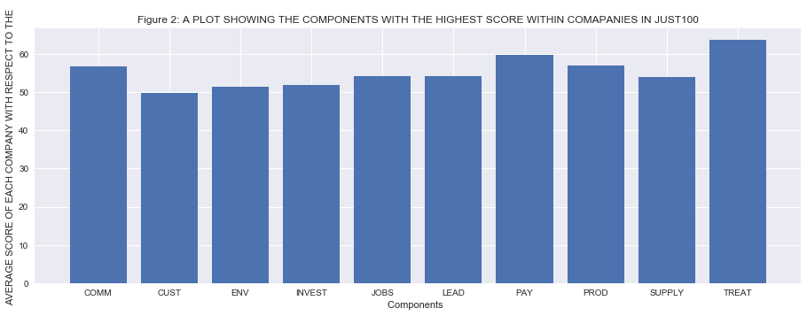

```python
# This shows a plot of average score of companies within the just100 ranking with respect to the rating components

x = ["PAY", "TREAT", "SUPPLY", "COMM",  "JOBS" , "PROD", "CUST", "LEAD", "ENV", "INVEST"]
y = meanJust100["Mean_Score"]

fig = plt.figure()
axes = fig.add_axes([1,1,2,1])
axes.bar(x,y)
plt.xlabel("Components  ")
plt.ylabel("AVERAGE SCORE OF EACH COMPANY WITH RESPECT TO THE ")
plt.title("Figure 2: A PLOT SHOWING THE COMPONENTS WITH THE HIGHEST SCORE WITHIN COMAPANIES IN JUST100")
```

### Result

#### The histogram above shows that the components with the highest score which are Treat with a score of 63.6., Pay with a score of 59.8 and Prod with a score of 56.9.

*This implies that if the companies with low ranking can improve on these three components there is a possibility to be part of the just100. As given in the data description these three component can be further explained as follows:*

*1. Treat : This implies a company's Commitment to Work-Life Balance, and Does Not Discriminate in Hiring, Firing and Promotion Practices.*

*2. Pay: This implies workers pay and benefits*

*3. Prod: Commitment to Producing Beneficial and Non-Harmful Products*

```
Text(0.5,1,'Figure 3: A box plot showing the minimum score, maximum score and average score of the top 400 companies ')
```

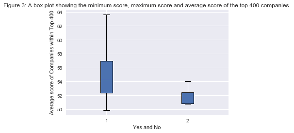

```python
#A box plot showing the comparison between the companies in the top 100 and the ones not in the top 100
data = meanJust100[["Mean_Score", "avgMean_ScoreNot100"]]
plt.boxplot(data,vert=True,patch_artist=True)
plt.xlabel("Yes and No")
plt.ylabel("Average score of Companies within Top 400")
plt.title("Figure 3: A box plot showing the minimum score, maximum score and average score of the top 400 companies ")
```

#### Result

```python
just400[["JUST_100", "WGT_SCORE"]].head()
```

|  | JUST_100 | WGT_SCORE |
| --- | --- | --- |
| 0 | No | 51.817449 |
| 1 | Yes | 60.214518 |
| 2 | No | 50.084911 |
| 3 | No | 52.567243 |
| 4 | No | 50.798780 |

```
Text(0.5,1,'Figure 4: Graph showing the number of companies in justTop100 and those not in justTop100')
```

[figure not shown]

```python
sns.swarmplot(x= "JUST_100", y= "WGT_SCORE", data= just400)
plt.xlabel("Yes implies companies in justTop 100 and No implies companies not in justTop 100")
plt.ylabel("Rating Weight Score")
plt.title("Figure 4: Graph showing the number of companies in justTop100 and those not in justTop100")
```

### Results

##### *1. This is a swarm plot showing the relationship between companies ranked in just100 i.e the Top 100 companies and the companies not in the rank with respect to their weight score. Less companies are found within the just100 compared to the those not in the just 100.*

##### *2. The plot also shows that companies in just100 has a maximum just scale of 64points and minimum of 52 points.*

##### *3. There should be a higher competition between companies so that there will be an increase in the maximum just scale, which is 64points in line with the plot in fig 4 .*